# Northern Water / Cache la Poudre Out-of-Sample Application

B Steele, Colorado State University, ROSSyndicate

last updated Sep 16, 2026

This notebook applies the current production model — `04_make_models.ipynb`’s 10-seed, XGBoost-only ensemble (40 fold models) — to out-of-sample remote sensing data from the Northern Water / Cache la Poudre (NW/CLP) service area, a separate project (`../NW-CLP-RS`) not used anywhere in this project’s training or holdout data, and reports performance against the observed Secchi depth record available for that area.

This replaces `4_apply_to_NW.R`, which applied an early, now-superseded 4-fold model using only spectral-ratio features and a stale copy of the band-correction coefficients. The current model needs more than spectral bands — its unanimous feature core includes site characteristics (elevation, LakeCat catchment land cover) and antecedent weather (gridMET) — so this notebook is substantially larger in scope than the script it replaces: it fetches those inputs fresh for the NW/CLP site set (neither exists for these sites anywhere in this project), the same way `pull_site_characteristics.Rmd` and `pull_weather_summaries.Rmd` do for the regional training set.

**Why XGBoost in R:** XGBoost’s JSON model format is directly loadable in R (`xgb.load()`) with no conversion step; this was verified directly (predictions from an R-loaded model matched Python’s own predictions to ~0.003 m) before starting this notebook.

**Known, deliberate gaps between this application and training** (see the corresponding questions this project’s user resolved before this notebook was written):

- **`shore_flag` is computed fresh from real waterbody geometry, not copied from AquaMatch’s QA join.** This file’s own `comid` turned out NOT to be a usable NHDPlusV2 identifier (confirmed against the LakeCat API directly — more below), so every site is re-matched to its NHDPlusV2 waterbody polygon via `nhdplusTools::get_waterbodies()`; `shore_flag` is then derived from actual distances to that polygon (`1` if the site point falls outside the matched polygon, or within 230 m of its boundary — the same 200 m site buffer + 30 m optical pixel threshold used to define the training-time flag; `0` otherwise), rather than reused from a different QA process.
- **Antecedent weather is anchored on the image date alone**, not `max(image_date, field_date)` as in training. At real deployment there is no known field-sample date to anchor on — this matches how the model would actually be used to score an arbitrary satellite pass.
- **Site characteristics are joined on a freshly-resolved NHDPlusV2 comid, not this file’s own `comid`/`permanent_identifier` columns.** Both were tested directly against the LakeCat API and neither matched (0/40 sites resolved in a spot check) — this file was very likely built against NHDPlusHR, a different identifier system than NHDPlusV2 (what StreamCat/LakeCat, and this project’s own training pipeline, are built on). `nhdplusTools::get_waterbodies()` resolves a real NHDPlusV2 comid per site by spatial match instead.

## Setup

```r
library(arrow)
library(tidyverse)
library(sf)
library(elevatr)
library(nhdplusTools)
library(StreamCatTools)
library(parallel)
library(climateR)
library(data.table)
library(xgboost)
library(jsonlite)
library(Metrics)

log <- function(...) cat(sprintf("[%s] ", format(Sys.time(), "%H:%M:%S")), sprintf(...), "\n")

NW_RS_PATH <- "../NW-CLP-RS/b_site_RS_data_acquisition/out/2025-04-01/NW_Poudre_Historical_collated_DSWE1_site_meta_v2025-04-01.feather"
SDD_PATH <- "data/waterQuality/harmonized/Secchi_data_NW_harmonized_2024-01-01.csv"
HANDOFFS_PATH <- "regional_clarity/aquamatch_files/downloads/lakeSR_collated_handoffs_GEEv2025-02-12_QAv2025-06-04.csv"
MODEL_DIR <- "regional_clarity/xg_models/v3_production"
ENSEMBLE_SEEDS <- 601:610

OUT_DIR <- "NW_CLP_application"
dir.create(OUT_DIR, showWarnings = FALSE)

# the elevation/waterbody/LakeCat and gridMET fetches below are each cached to
# OUT_DIR as a feather file; re-running the notebook loads from cache instead
# of re-fetching. Set to TRUE to force a fresh fetch (e.g. after the RS input
# file's site set changes).
FORCE_REFRESH_CACHE <- FALSE

ROSS_LT_PAL <- c("#002EA3", "#E70870", "#256BF5", "#745CFB", "#1E4D2B", "#56104E", "#888888")
```

## Read and QA-filter the RS data

Same generous QA filters used throughout this project (`pCount_dswe1/pCount_dswe_gt0 > 0.5`, `pCount_dswe1 > 8`, `prop_clouds == 0`). The image date isn’t in its own column in this file version — it’s embedded in `system:index` (e.g. `"1_1_LT04_033032_19830119_3"` or `"2_LE07_033032_19990710_1"`, an 8-digit `YYYYMMDD` token second from the end regardless of how many leading tokens the mission/path-row segment uses).

```r
NW_RS_raw <- read_feather(NW_RS_PATH)
log("raw: %s rows, %s unique sites (r_id)", nrow(NW_RS_raw), n_distinct(NW_RS_raw$r_id))
```

```
## [07:45:22]  raw: 321637 rows, 485 unique sites (r_id)
```

```r
NW_RS <- NW_RS_raw %>%
  mutate(across(c(pCount_dswe1, pCount_dswe_gt0, prop_clouds,
                  med_Red, med_Blue, med_Green, med_Nir, med_Swir1, med_Swir2, med_SurfaceTemp),
                as.numeric)) %>%
  filter(pCount_dswe1 / pCount_dswe_gt0 > 0.5, pCount_dswe1 > 8, prop_clouds == 0)

# date: second-to-last "_"-delimited token of system:index, regardless of
# leading-token count (LANDSAT_4/5 carry one extra leading token vs. 7/8/9)
index_parts <- str_split(NW_RS$`system:index`, "_")
NW_RS <- NW_RS %>%
  mutate(date = as.Date(map_chr(index_parts, ~ .x[length(.x) - 1]), format = "%Y%m%d"),
         lat = Latitude, lon = Longitude)
stopifnot("date parsing failed for some rows" = sum(is.na(NW_RS$date)) == 0)

log("QA-filtered: %s rows, %s unique sites, date range %s to %s",
    nrow(NW_RS), n_distinct(NW_RS$r_id), min(NW_RS$date), max(NW_RS$date))
```

```
## [07:45:24]  QA-filtered: 188031 rows, 408 unique sites, date range 1983-01-10 to 2025-03-27
```

## Cross-sensor band harmonization

Same Gardner coefficients (referenced to Landsat 7) this project’s own production pipeline uses (`aquamatch_files/downloads/lakeSR_collated_handoffs_...csv`), not `4_apply_to_NW.R`’s stale standalone copy — this file’s `mission` values (`"LANDSAT_4"`, etc.) are the full GEE-style names rather than this project’s `"LT04"`-style codes, so the sensor-family mapping is re-derived here rather than reused directly.

```r
am_corr_LS7 <- read_csv(HANDOFFS_PATH, show_col_types = FALSE) %>%
  filter(correction == "Gardner", dswe == "DSWE1", sat_to == "LS7") %>%
  pivot_longer(cols = c(intercept, B1, B2, min_in_val, max_in_val),
               names_to = "int_coef", values_to = "value") %>%
  mutate(new_column = paste(band, int_coef, sep = "_")) %>%
  select(-c(band, int_coef, slope, method)) %>%
  pivot_wider(names_from = new_column, values_from = value)

NW_RS_corr <- NW_RS %>%
  mutate(sat_corr = case_when(mission %in% c("LANDSAT_4", "LANDSAT_5") ~ "LS5",
                              mission == "LANDSAT_7" ~ "LS7",
                              mission %in% c("LANDSAT_8", "LANDSAT_9") ~ "LS8",
                              TRUE ~ NA_character_),
         atm_corr_LaSRC = as.numeric(mission %in% c("LANDSAT_8", "LANDSAT_9"))) %>%
  left_join(am_corr_LS7, by = "sat_corr")

NW_RS_corr <- NW_RS_corr %>%
  mutate(red_corr7 = med_Red_intercept + med_Red_B1 * med_Red + med_Red_B2 * med_Red^2,
         green_corr7 = med_Green_intercept + med_Green_B1 * med_Green + med_Green_B2 * med_Green^2,
         blue_corr7 = med_Blue_intercept + med_Blue_B1 * med_Blue + med_Blue_B2 * med_Blue^2,
         nir_corr7 = med_Nir_intercept + med_Nir_B1 * med_Nir + med_Nir_B2 * med_Nir^2,
         swir1_corr7 = med_Swir1_intercept + med_Swir1_B1 * med_Swir1 + med_Swir1_B2 * med_Swir1^2,
         swir2_corr7 = med_Swir2_intercept + med_Swir2_B1 * med_Swir2 + med_Swir2_B2 * med_Swir2^2,
         temp_corr7 = med_SurfaceTemp_intercept + med_SurfaceTemp_B1 * med_SurfaceTemp +
           med_SurfaceTemp_B2 * med_SurfaceTemp^2) %>%
  mutate(red_corr7 = if_else(sat_corr == "LS7", med_Red, red_corr7),
         green_corr7 = if_else(sat_corr == "LS7", med_Green, green_corr7),
         blue_corr7 = if_else(sat_corr == "LS7", med_Blue, blue_corr7),
         nir_corr7 = if_else(sat_corr == "LS7", med_Nir, nir_corr7),
         swir1_corr7 = if_else(sat_corr == "LS7", med_Swir1, swir1_corr7),
         swir2_corr7 = if_else(sat_corr == "LS7", med_Swir2, swir2_corr7),
         temp_corr7 = if_else(sat_corr == "LS7", med_SurfaceTemp, temp_corr7)) %>%
  select(-all_of(names(am_corr_LS7)[names(am_corr_LS7) != "sat_corr"]))
```

## Spectral indices

R port of `python/features.py`’s `add_spectral_indices()` — the same 9 curated ratios/indices, kept in exact sync with that module rather than the ~50-ratio set `4_apply_to_NW.R` used.

```r
NW_RS_ml <- NW_RS_corr %>%
  mutate(BR = blue_corr7 / red_corr7,
         BG = blue_corr7 / green_corr7,
         NR = nir_corr7 / red_corr7,
         GR = green_corr7 / red_corr7,
         fai = nir_corr7 - (red_corr7 + (swir1_corr7 - red_corr7) * ((830 - 660) / (1650 - 660))),
         NDVI = (nir_corr7 - red_corr7) / (nir_corr7 + red_corr7),
         NDSSI = (blue_corr7 - nir_corr7) / (blue_corr7 + nir_corr7),
         NDWI = (green_corr7 - nir_corr7) / (green_corr7 + nir_corr7),    # McFeeters 1996
         MNDWI = (green_corr7 - swir1_corr7) / (green_corr7 + swir1_corr7)) %>%  # Xu 2006
  mutate(across(c(BR, BG, NR, GR, fai, NDVI, NDSSI, NDWI, MNDWI),
                ~ if_else(is.finite(.x), .x, NA_real_)))

log("%s rows, %s unique sites after band correction + spectral indices", nrow(NW_RS_ml), n_distinct(NW_RS_ml$r_id))
```

```
## [07:45:25]  188031 rows, 408 unique sites after band correction + spectral indices
```

## Site characteristics and `shore_flag`

Elevation is straightforward (AWS terrain tiles, same as `pull_site_characteristics.Rmd`). Catchment characteristics need an NHDPlusV2 `comid` to join into LakeCat — this file’s own `comid` and `permanent_identifier` columns were both tested directly against the live LakeCat API and neither resolved (0/40 in a spot check; a raw API call against one `permanent_identifier` value returned an explicit 404), so every site is re-matched to its NHDPlusV2 waterbody polygon here via `nhdplusTools::get_waterbodies()` — a single bulk fetch over the full site extent, then a local nearest-feature spatial join, mirroring `01_filter_AquaMatch_Data.Rmd`’s own “fetch once regionally, join locally” pattern rather than one API call per site.

The same resolved polygon geometry gives `shore_flag` for free: `dist_to_wb` (0 if the site point falls inside its matched waterbody, otherwise the distance to it) and `dist_to_shore` (distance to the polygon’s boundary specifically) are both computed directly, and combined the same way the training-time flag was defined (`shore_flag = 1` if the site is outside its matched waterbody **or** within 230 m of its shoreline).

This block, and the gridMET weather pull below, are the slowest part of the notebook and cache their results to `OUT_DIR` (elevation/waterbody/LakeCat → `NW_CLP_site_characteristics.feather`; weather → `NW_CLP_weather_raw.feather` / `NW_CLP_weather_summaries.feather`). A re-run loads straight from cache; set `FORCE_REFRESH_CACHE <- TRUE` in the setup chunk (e.g. after the input site set changes) to force a fresh fetch.

```r
site_char_cache <- file.path(OUT_DIR, "NW_CLP_site_characteristics.feather")

if (!FORCE_REFRESH_CACHE && file.exists(site_char_cache)) {
  sites_unique <- read_feather(site_char_cache)
  log("loaded cached site characteristics (%s): %s sites", site_char_cache, nrow(sites_unique))
} else {
  sites_unique <- NW_RS_ml %>% distinct(r_id, lat, lon)
  log("n unique sites: %s", nrow(sites_unique))

  pts_sf <- st_as_sf(sites_unique, coords = c("lon", "lat"), crs = 4326, remove = FALSE)

  t0 <- Sys.time()
  elev <- get_elev_point(pts_sf, src = "aws", z = 9)
  log("elevation fetch took %.1f min", as.numeric(difftime(Sys.time(), t0, units = "mins")))
  elev_df <- st_drop_geometry(elev) %>% select(r_id, elevation_m = elevation)
  sites_unique <- sites_unique %>% left_join(elev_df, by = "r_id")

  # fresh NHDPlusV2 waterbody match: one bulk fetch over the full site extent,
  # then a local nearest-feature join per site
  aoi <- st_convex_hull(st_union(pts_sf)) %>% st_buffer(0.01)
  t0 <- Sys.time()
  waterbodies <- get_waterbodies(AOI = aoi)
  log("waterbody fetch took %.1f s, %s polygons over the site extent",
      as.numeric(difftime(Sys.time(), t0, units = "secs")), nrow(waterbodies))

  nearest_idx <- st_nearest_feature(pts_sf, waterbodies)
  matched_wb <- waterbodies[nearest_idx, ]
  dist_to_wb <- as.numeric(st_distance(pts_sf, matched_wb, by_element = TRUE))
  dist_to_shore <- as.numeric(st_distance(pts_sf, st_boundary(matched_wb), by_element = TRUE))

  sites_unique <- sites_unique %>%
    mutate(comid = as.character(matched_wb$comid),
           dist_to_wb = dist_to_wb, dist_to_shore = dist_to_shore,
           shore_flag = as.numeric(dist_to_wb > 0 | dist_to_shore < 230))
  log("shore_flag distribution:"); print(table(sites_unique$shore_flag))

  lakecat_metrics <- paste(c(
    "pctimp2006", "pcturbhi2006", "pcturblo2006", "pcturbmd2006", "pcturbop2006",
    "pctconif2006", "pctdecid2006", "pctmxfst2006",
    "pcthbwet2006", "pctwdwet2006", "pctcrop2006"
  ), collapse = ",")

  comids <- unique(na.omit(sites_unique$comid))
  chunk_size <- 200
  chunks <- split(comids, ceiling(seq_along(comids) / chunk_size))
  # a chunk where NONE of its comids are LakeCat-covered throws rather than
  # returning empty (seen directly while developing this notebook) - catch
  # that per chunk so one bad chunk doesn't abort the whole fetch
  lakecat_raw <- purrr::map_dfr(chunks, function(ch) {
    tryCatch(lc_get_data(comid = paste(ch, collapse = ","), metric = lakecat_metrics,
                         aoi = "catchment", showAreaSqKm = TRUE),
             error = function(e) { log("LakeCat chunk failed (0 covered): %s", conditionMessage(e)); tibble() })
  })
  log("LakeCat rows returned: %s / %s comids requested", nrow(lakecat_raw), length(comids))

  lakecat <- lakecat_raw %>%
    mutate(comid = as.character(comid),
           pct_forest_2006 = pctconif2006cat + pctdecid2006cat + pctmxfst2006cat,
           pct_wetland_2006 = pcthbwet2006cat + pctwdwet2006cat,
           pct_urban_2006 = pcturbhi2006cat + pcturblo2006cat + pcturbmd2006cat + pcturbop2006cat) %>%
    select(comid, catchment_area_sqkm = catareasqkm,
           pct_impervious_2006 = pctimp2006cat, pct_urban_2006, pct_forest_2006,
           pct_cropland_2006 = pctcrop2006cat, pct_wetland_2006)

  sites_unique <- sites_unique %>% left_join(lakecat, by = "comid")
  log("sites with LakeCat data: %s / %s", sum(!is.na(sites_unique$pct_impervious_2006)), nrow(sites_unique))

  write_feather(sites_unique, site_char_cache)
}
```

```
## [07:45:25]  loaded cached site characteristics (NW_CLP_application/NW_CLP_site_characteristics.feather): 408 sites
```

## Antecedent weather

Same gridMET fetch + rolling-window summary as `pull_weather_summaries.Rmd`, run fresh for the NW/CLP sites — anchored on the image date alone (see the note at the top of this notebook).

```r
MAX_WINDOW_DAYS <- 30
WINDOWS <- c(1, 3, 7, 30)
VARS <- c("pr", "tmmx", "tmmn", "srad")
N_WORKERS <- 8

weather_summary_cache <- file.path(OUT_DIR, "NW_CLP_weather_summaries.feather")
weather_raw_cache <- file.path(OUT_DIR, "NW_CLP_weather_raw.feather")

if (!FORCE_REFRESH_CACHE && file.exists(weather_summary_cache)) {
  log("weather summaries cache found (%s), skipping gridMET fetch", weather_summary_cache)
} else if (!FORCE_REFRESH_CACHE && file.exists(weather_raw_cache)) {
  weather_raw <- read_feather(weather_raw_cache)
  log("loaded cached raw weather (%s): %s rows, skipping gridMET fetch", weather_raw_cache, nrow(weather_raw))
} else {
  site_ranges <- NW_RS_ml %>%
    group_by(r_id, lat, lon) %>%
    summarize(min_date = min(date) - (MAX_WINDOW_DAYS + 5), max_date = max(date), .groups = "drop")
  log("fetching gridMET for %s sites", nrow(site_ranges))

  fetch_one <- function(i, site_ranges) {
    row <- site_ranges[i, ]
    fetch <- function() {
      pt <- sf::st_as_sf(data.frame(lon = row$lon, lat = row$lat), coords = c("lon", "lat"), crs = 4326)
      res <- getGridMET(AOI = pt, varname = VARS,
                         startDate = as.character(row$min_date), endDate = as.character(row$max_date))
      res$r_id <- row$r_id
      res
    }
    tryCatch(fetch(), error = function(e) {
      Sys.sleep(2)
      tryCatch(fetch(), error = function(e2) data.frame(r_id = row$r_id, error = conditionMessage(e2)))
    })
  }

  t0 <- Sys.time()
  cl <- makeCluster(N_WORKERS, type = "PSOCK")
  clusterEvalQ(cl, { suppressMessages(library(climateR)); suppressMessages(library(sf)) })
  clusterExport(cl, c("site_ranges", "VARS", "fetch_one"))
  results <- parLapply(cl, seq_len(nrow(site_ranges)), fetch_one, site_ranges = site_ranges)
  stopCluster(cl)
  log("fetch took %.1f min", as.numeric(difftime(Sys.time(), t0, units = "mins")))

  ok <- Filter(function(x) !"error" %in% names(x), results)
  failed <- Filter(function(x) "error" %in% names(x), results)
  log("succeeded: %s sites, failed: %s sites", length(ok), length(failed))
  if (length(failed) > 0) {
    write_csv(bind_rows(failed), file.path(OUT_DIR, "NW_CLP_weather_fetch_failures.csv"))
  }

  weather_raw <- bind_rows(ok)
  write_feather(weather_raw, weather_raw_cache)
}
```

```
## [07:45:25]  weather summaries cache found (NW_CLP_application/NW_CLP_weather_summaries.feather), skipping gridMET fetch
```

```r
if (!FORCE_REFRESH_CACHE && file.exists(weather_summary_cache)) {
  weather_summaries <- as.data.table(read_feather(weather_summary_cache))
  log("loaded cached weather summaries (%s): %s rows, %s cols",
      weather_summary_cache, nrow(weather_summaries), ncol(weather_summaries))
} else {
  weather <- weather_raw %>%
    mutate(date = as.Date(date),
           precip_mm = pr, tmax_degC = tmmx - 273.15, tmin_degC = tmmn - 273.15,
           tmean_degC = (tmax_degC + tmin_degC) / 2, srad_Wm2 = srad) %>%
    select(r_id, date, precip_mm, tmax_degC, tmin_degC, tmean_degC, srad_Wm2)

  setDT(weather)
  setorder(weather, r_id, date)
  site_splits <- split(weather, by = "r_id", keep.by = TRUE)

  make_summary_one_site <- function(df) {
    site_id <- df$r_id[1]
    full_days <- data.table(date = seq(min(df$date), max(df$date), by = "1 day"))
    df <- merge(full_days, df[, -"r_id"], by = "date", all.x = TRUE)
    df[, r_id := site_id]
    for (w in WINDOWS) {
      df[[paste0("precip_mm_prev", w)]] <- frollsum(df$precip_mm, n = w)
      df[[paste0("tmax_degC_prev", w)]] <- frollapply(df$tmax_degC, N = w, FUN = max)
      df[[paste0("tmean_degC_prev", w)]] <- frollmean(df$tmean_degC, n = w)
      df[[paste0("tmin_degC_prev", w)]] <- frollapply(df$tmin_degC, N = w, FUN = min)
      df[[paste0("srad_Wm2_prev", w)]] <- frollmean(df$srad_Wm2, n = w)
    }
    df[, date := date + 1]  # window on `date` covers the w days strictly BEFORE date
    df
  }

  # frollapply() (used for the rolling max/min above) forks worker processes via
  # parallel::mcparallel() whenever data.table has >1 thread available - Positron
  # disallows forking the R session, so force single-threaded (non-forking) here
  old_dt_threads <- getDTthreads()
  setDTthreads(1)
  t0 <- Sys.time()
  weather_summaries <- rbindlist(lapply(site_splits, make_summary_one_site), fill = TRUE)
  setDTthreads(old_dt_threads)
  weather_summaries <- weather_summaries[!is.na(r_id)]
  log("weather summaries took %.1f min: %s rows, %s cols",
      as.numeric(difftime(Sys.time(), t0, units = "mins")), nrow(weather_summaries), ncol(weather_summaries))
  write_feather(as.data.frame(weather_summaries), weather_summary_cache)
}
```

```
## [07:45:26]  loaded cached weather summaries (NW_CLP_application/NW_CLP_weather_summaries.feather): 5151692 rows, 27 cols
```

## Assemble the model input table

Joins bands/indices + site characteristics (including the freshly-computed `shore_flag`) + weather.

```r
model_input <- NW_RS_ml %>%
  left_join(sites_unique %>% select(-lat, -lon, -comid), by = "r_id") %>%
  left_join(as.data.frame(weather_summaries), by = c("r_id", "date")) %>%
  as.data.frame()  # weather_summaries carries a data.table class through the join otherwise,
                    # which breaks plain `df[, feats]` column selection below

log("model input: %s rows, %s cols", nrow(model_input), ncol(model_input))
```

```
## [07:45:28]  model input: 188031 rows, 269 cols
```

```r
log("rows missing weather: %s / %s", sum(is.na(model_input$precip_mm_prev30)), nrow(model_input))
```

```
## [07:45:28]  rows missing weather: 0 / 188031
```

```r
log("rows missing LakeCat catchment data: %s / %s", sum(is.na(model_input$pct_impervious_2006)), nrow(model_input))
```

```
## [07:45:28]  rows missing LakeCat catchment data: 0 / 188031
```

```r
# training now applies python/features.py's coarsen_site_features() -
# catchment_area_sqkm winsorized at the training data's 99th percentile
# (617.1 km2) then log-scale binned, pct_*_2006 land-cover fractions rounded
# to the nearest percentage point - to keep a heavily-resampled or
# catchment-outlier waterbody's static per-comid LakeCat values from acting
# as a de facto waterbody ID a tree can key a memorized SDD value off of.
# The winsorization cap is a fixed constant fit once on the training
# distribution (see features.py's CATCHMENT_WINSORIZE_CAP_SQKM docstring),
# not recomputed here, so any NW/CLP reservoir above it gets pulled down to
# the same capped value production training used - the trained models
# expect that same resolution at inference time, so it's replicated here
# rather than passing full-precision LakeCat values into a model that never
# saw them
CATCHMENT_WINSORIZE_CAP_SQKM <- 617.1

model_input <- model_input %>%
  mutate(catchment_area_sqkm = 10^round(log10(pmin(catchment_area_sqkm, CATCHMENT_WINSORIZE_CAP_SQKM)), 1),
         across(c(pct_impervious_2006, pct_urban_2006, pct_forest_2006,
                  pct_cropland_2006, pct_wetland_2006), ~round(.x, 0)))
```

## Load the 10-seed XGBoost ensemble and predict

```r
seed_preds <- vector("list", length(ENSEMBLE_SEEDS))

for (i in seq_along(ENSEMBLE_SEEDS)) {
  seed <- ENSEMBLE_SEEDS[i]
  seed_dir <- file.path(MODEL_DIR, paste0("seed", seed))
  feats <- fromJSON(file.path(seed_dir, "final_tune_xgboost.json"))$features

  missing_cols <- setdiff(feats, names(model_input))
  stopifnot("model input is missing columns this seed's model needs" = length(missing_cols) == 0)

  X <- as.matrix(model_input[, feats])
  fold_preds <- matrix(NA_real_, nrow = nrow(X), ncol = 4)
  for (fold in 1:4) {
    booster <- xgb.load(file.path(seed_dir, paste0("xgboost_fold", fold, ".json")))
    fold_preds[, fold] <- predict(booster, X)
  }
  seed_preds[[i]] <- rowMeans(fold_preds)
  log("seed%s: predicted (%s features)", seed, length(feats))
}
```

```
## [07:45:37]  seed601: predicted (26 features)
## [07:45:42]  seed602: predicted (26 features)
## [07:45:45]  seed603: predicted (33 features)
## [07:45:53]  seed604: predicted (29 features)
## [07:46:00]  seed605: predicted (26 features)
## [07:46:06]  seed606: predicted (28 features)
## [07:46:14]  seed607: predicted (28 features)
## [07:46:19]  seed608: predicted (29 features)
## [07:46:23]  seed609: predicted (30 features)
## [07:46:29]  seed610: predicted (33 features)
```

```r
model_input$pred_sdd <- rowMeans(do.call(cbind, seed_preds))
log("prediction summary:"); print(summary(model_input$pred_sdd))
```

```
## [07:46:29]  prediction summary:
```

```
##    Min. 1st Qu.  Median    Mean 3rd Qu.    Max.
## -0.5809  0.9059  1.5011  1.8516  2.5504  8.9122
```

## Match to observed Secchi depth

Same GNIS-name harmonization `4_apply_to_NW.R` used (a handful of names differ between the water-quality record’s `feature` and this RS file’s NHD-derived `gnis_name`).

Matched with the same ±5-day window `02_make_matches.Rmd` uses for the regional training data, rather than requiring an exact same-day match — an exact-date join silently drops any in-situ observation that doesn’t happen to fall on a satellite overpass date, which is most of them, and undercounts the evaluable pairs relative to every other evaluation in this project. Unlike training (where the same image legitimately pairs with more than one nearby SDD measurement as separate rows), evaluation de-duplicates by **image**, not by observation: each unique overpass keeps only the single SDD measurement closest in time to it, so a dense field-sampling week landing inside one overpass’s window doesn’t score that one static prediction against several different observed values as if it were several independent tests of the model. `time_diff` (predicted image date minus observed sample date, in days) is kept for the same match-quality check `05_evaluate_ensemble.ipynb` runs on the regional holdout.

Candidate pairs are also screened for a heavy single-day rain event between the image date and the field date — mirroring the gap-based rain filter (`24_gap_period_rain_check.R` / `25_apply_gap_rain_filter.R`) built on the `outlier-removal-rework` branch but never merged into the production `02_make_matches.Rmd` pipeline, so the regional training data isn’t screened for this. Applied here as a deliberate, higher bar for the out-of-sample evaluation specifically. Screening happens on **candidates**, before the closest-in-time selection above, not after: a heavy rain event during an observation’s single nearest candidate image would otherwise drop that observation outright even when a perfectly good, only slightly-further-away, uncontaminated image is also available in the window. Direction-agnostic (checked over `[min(image date, field date), max(image date, field date)]`), matching the original filter.

```r
MATCH_WINDOW_DAYS <- 5
HEAVY_RAIN_MM <- 25.4  # NOAA/EPA "heavy precipitation day" threshold (1 inch/24hr)

NW_sdd <- read_csv(SDD_PATH, show_col_types = FALSE) %>%
  mutate(gnis_name = case_when(feature == "Carter Lake" ~ "Carter Lake Reservoir",
                               feature == "Shadow Mountain Reservoir" ~ "Shadow Mountain Lake",
                               feature == "Granby Reservoir" ~ "Lake Granby",
                               TRUE ~ feature))

res_names <- unique(NW_sdd$gnis_name)
log("%s reservoirs with observed SDD: %s", length(res_names), paste(res_names, collapse = ", "))
```

```
## [07:46:29]  8 reservoirs with observed SDD: Shadow Mountain Lake, Grand Lake, Carter Lake Reservoir, Lake Granby, Horsetooth Reservoir, Willow Creek Reservoir, Windy Gap Reservoir, Columbine Lake
```

```r
pred_at_obs_res <- model_input %>%
  filter(gnis_name %in% res_names) %>%
  summarise(predicted = mean(pred_sdd), .by = c(date, gnis_name)) %>%
  rename(date_pred = date)

obs_at_res <- NW_sdd %>%
  summarise(observed = mean(value), .by = c(date, gnis_name)) %>%
  rename(date_obs = date)

# every (obs, pred) candidate pair per reservoir within the window
candidates <- obs_at_res %>%
  inner_join(pred_at_obs_res, by = "gnis_name") %>%
  mutate(time_diff = as.numeric(date_pred - date_obs)) %>%
  filter(abs(time_diff) <= MATCH_WINDOW_DAYS)
```

```r
# raw daily gridMET precip isn't kept in scope once weather_summaries loads
# from cache (see weather-fetch above), so read it back explicitly here
weather_raw_rain <- read_feather(weather_raw_cache) %>% mutate(date = as.Date(date))
site_res_lookup <- model_input %>% distinct(r_id, gnis_name)
weather_raw_res <- weather_raw_rain %>%
  inner_join(site_res_lookup, by = "r_id") %>%
  select(gnis_name, date, pr)

# peak single-day precip at ANY site in the reservoir, strictly between the
# earlier and later of the image date and the field date - a data.table
# non-equi (interval) join, the same approach 24_gap_period_rain_check.R
# uses at the individual-site level in the regional pipeline
candidates <- candidates %>%
  mutate(gap_start = pmin(date_obs, date_pred), gap_end = pmax(date_obs, date_pred),
         cand_id = row_number())

candidates_dt <- as.data.table(candidates)
wx_dt <- as.data.table(weather_raw_res)
setkey(wx_dt, gnis_name, date)

joined <- wx_dt[candidates_dt, on = .(gnis_name, date > gap_start, date <= gap_end),
                nomatch = NA, allow.cartesian = TRUE]
gap_max <- joined[, .(gap_max_precip_mm = max(pr, na.rm = TRUE)), by = cand_id]
gap_max[!is.finite(gap_max_precip_mm), gap_max_precip_mm := 0]

candidates <- candidates %>%
  left_join(as.data.frame(gap_max), by = "cand_id") %>%
  mutate(gap_max_precip_mm = coalesce(gap_max_precip_mm, 0))

n_flagged <- sum(candidates$gap_max_precip_mm >= HEAVY_RAIN_MM)
log("%s / %s candidate (obs, image) pairs flagged for a heavy single-day rain event (>= %.1f mm) in their gap - excluded before closest-match selection",
    n_flagged, nrow(candidates), HEAVY_RAIN_MM)
```

```
## [07:46:31]  8 / 2076 candidate (obs, image) pairs flagged for a heavy single-day rain event (>= 25.4 mm) in their gap - excluded before closest-match selection
```

```r
candidates <- candidates %>%
  filter(gap_max_precip_mm < HEAVY_RAIN_MM) %>%
  select(-gap_start, -gap_end, -cand_id, -gap_max_precip_mm)

# only now, among the rain-screened candidates, keep the single SDD
# observation closest in time to each image - de-duplicating by observation
# instead would still let the same image be the nearest available match for
# several different field visits (e.g. a dense sampling week landing inside
# one overpass's window), which scores that one static prediction against
# each of those visits separately and counts it multiple times in the
# evaluation metrics. De-duplicating by image instead keeps each unique
# overpass contributing exactly one (prediction, observation) pair.
pred_obs <- candidates %>%
  arrange(gnis_name, date_pred, abs(time_diff)) %>%
  distinct(gnis_name, date_pred, .keep_all = TRUE) %>%
  rename(date = date_obs) %>%
  select(-date_pred)

n_obs_reused <- nrow(pred_obs) - n_distinct(pred_obs %>% select(gnis_name, date))
log("%s matched (image, reservoir) pairs within +/- %s days, one SDD measurement kept per image",
    nrow(pred_obs), MATCH_WINDOW_DAYS)
```

```
## [07:46:31]  1165 matched (image, reservoir) pairs within +/- 5 days, one SDD measurement kept per image
```

```r
log("%s of those SDD measurements were the closest available observation for more than one image",
    n_obs_reused)
```

```
## [07:46:31]  209 of those SDD measurements were the closest available observation for more than one image
```

```r
log("time_diff (pred image date - obs sample date): mean=%.2f, median=%.1f, range=[%s, %s] days",
    mean(pred_obs$time_diff), median(pred_obs$time_diff), min(pred_obs$time_diff), max(pred_obs$time_diff))
```

```
## [07:46:31]  time_diff (pred image date - obs sample date): mean=0.04, median=0.0, range=[-5, 5] days
```

```r
# same diagnostic 05_evaluate_ensemble.ipynb runs on the regional holdout: does
# looser match-ups (larger |time_diff|) correlate with worse prediction error?
pred_obs <- pred_obs %>% mutate(abs_error = abs(predicted - observed))
gap_corr <- cor(abs(pred_obs$time_diff), pred_obs$abs_error)
log("Pearson r(|time_diff|, abs_error) = %.3f (n=%s)", gap_corr, nrow(pred_obs))
```

```
## [07:46:31]  Pearson r(|time_diff|, abs_error) = 0.013 (n=1165)
```

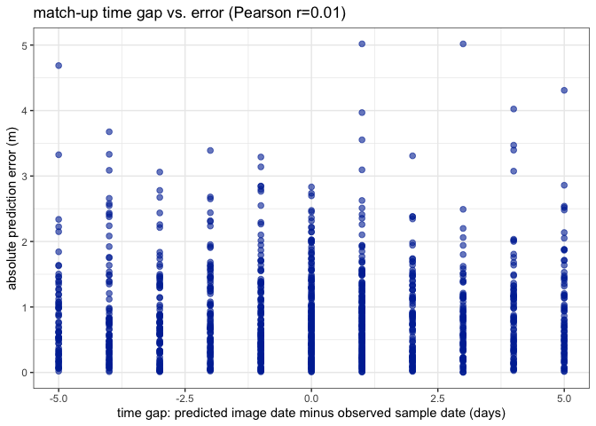

```r
ggplot(pred_obs, aes(x = time_diff, y = abs_error)) +
  geom_point(size = 2, alpha = 0.6, color = ROSS_LT_PAL[1]) +
  labs(x = "time gap: predicted image date minus observed sample date (days)",
       y = "absolute prediction error (m)",
       title = sprintf("match-up time gap vs. error (Pearson r=%.2f)", gap_corr)) +
  theme_bw()
```

## Predicted vs. observed

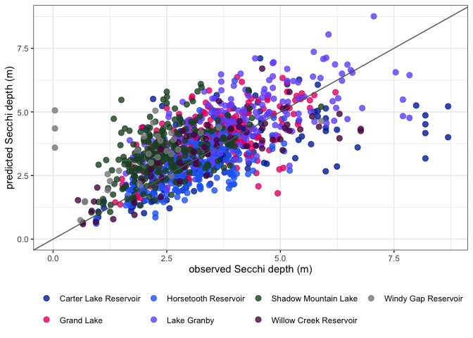

```r
pred_obs <- pred_obs |>
  mutate(resid = predicted-observed)
ggplot(pred_obs, aes(x = observed, y = predicted, color = gnis_name)) +
  geom_point(size = 2.5, alpha = 0.8) +
  geom_abline(slope = 1, intercept = 0, color = "grey40") +
  scale_x_continuous(limits = c(0, NA)) +
  scale_y_continuous(limits = c(0, NA)) +
  scale_color_manual(values = ROSS_LT_PAL) +
  labs(x = "observed Secchi depth (m)", y = "predicted Secchi depth (m)", color = NULL) +
  theme_bw() +
  theme(legend.position = "bottom")
```

```r
evals_NW <- pred_obs %>%
  summarise(rmse = rmse(observed, predicted),
            mae = mae(observed, predicted),
            mape = mape(observed, predicted),
            bias = bias(observed, predicted),
            p.bias = percent_bias(observed, predicted),
            smape = smape(observed, predicted),
            r2 = cor(observed, predicted)^2,
            n = n())
evals_NW
```

```
## # A tibble: 1 × 8
##    rmse   mae  mape   bias p.bias smape    r2     n
##   <dbl> <dbl> <dbl>  <dbl>  <dbl> <dbl> <dbl> <int>
## 1  1.13 0.863 0.572 -0.321 -0.435 0.260 0.389  1165
```

```r
evals_NW_by_res <- pred_obs %>%
  summarise(rmse = rmse(observed, predicted), bias = bias(observed, predicted),
            r2 = cor(observed, predicted)^2, n = n(),
            .by = gnis_name) %>%
  arrange(desc(rmse))
evals_NW_by_res
```

```
## # A tibble: 7 × 5
##   gnis_name               rmse   bias    r2     n
##   <chr>                  <dbl>  <dbl> <dbl> <int>
## 1 Windy Gap Reservoir    1.86  -1.38  0.159    29
## 2 Shadow Mountain Lake   1.27  -0.909 0.246   251
## 3 Lake Granby            1.22  -0.532 0.427   165
## 4 Carter Lake Reservoir  1.21   0.125 0.348   209
## 5 Grand Lake             1.03  -0.476 0.354   216
## 6 Willow Creek Reservoir 0.935  0.106 0.655    64
## 7 Horsetooth Reservoir   0.796  0.224 0.340   231
```

## Time series

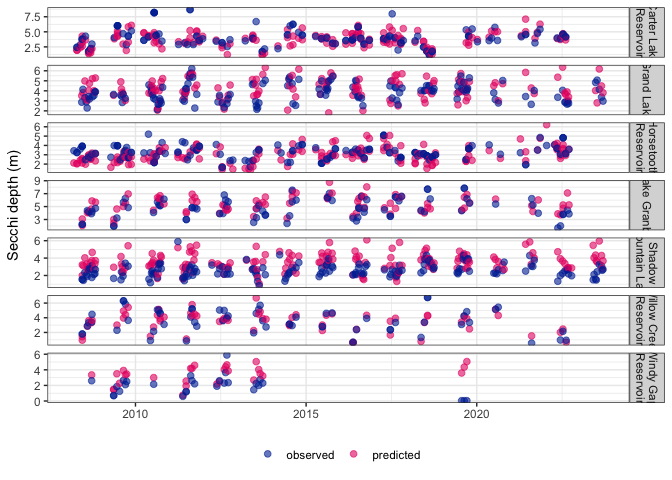

```r
pred_obs %>%
filter(date > ymd("2008-01-01")) %>%

  pivot_longer(c(predicted, observed), names_to = "source", values_to = "value") %>%
  ggplot(aes(x = date, y = value, color = source)) +
  geom_point(size = 2, alpha = 0.6) +
  facet_grid(gnis_name ~ ., scales = "free_y", labeller = label_wrap_gen(15)) +
  scale_color_manual(values = ROSS_LT_PAL) +
  labs(x = NULL, y = "Secchi depth (m)", color = NULL) +
  theme_bw() +
  theme(legend.position = "bottom")
```

## Export

```r
write_csv(pred_obs, file.path(OUT_DIR, "NW_CLP_pred_obs.csv"))
write_csv(evals_NW, file.path(OUT_DIR, "NW_CLP_eval_metrics.csv"))
write_csv(evals_NW_by_res, file.path(OUT_DIR, "NW_CLP_eval_metrics_by_reservoir.csv"))

# full out-of-sample prediction record (not just the subset with a matched observation)
write_feather(model_input %>% select(r_id, date, mission, gnis_name, comid, lat, lon, pred_sdd),
              file.path(OUT_DIR, "NW_CLP_full_predictions.feather"))
log("wrote outputs to %s/", OUT_DIR)
```

```
## [07:46:31]  wrote outputs to NW_CLP_application/
```

## Summary

**Out-of-sample transfer got worse on the current production model, even though in-region performance got substantially better.** The regional holdout (now `holdout_seed=12`, band RANSAC redesigned to majority-vote, rain-filtered matchups, catchment-area winsorized) improved to RMSE 1.259 m / R² 0.626 / bias +0.148 m — better on every metric than any earlier configuration. This NW/CLP evaluation moved the opposite direction over the same changes: RMSE rose from 0.998 m to 1.128 m and R² fell from 0.436 to 0.389. That’s a real, unresolved tension worth keeping visible rather than averaging away: whatever changed about the model to help it generalize better *within* the training region’s HUC8 structure did not carry over to this specific out-of-region transfer, and may have made it modestly worse. Plausible contributors not yet investigated: catchment-area winsorization changes the model’s relationship to catchment size specifically in a range NW/CLP’s reservoirs may or may not fall into similarly to the training region’s; a different holdout seed trains on a different subset of hard basins, which could shift what the model has learned to generalize from in ways that don’t track equally across every downstream application.

**The bias also got more negative** (underprediction deepened from −0.130 m to −0.321 m), the same direction as the R²/RMSE degradation, consistent with a genuine shift in how the model transfers to this basin rather than two unrelated effects. The regional holdout’s own bias moved the other way (+0.400 m or worse in every earlier configuration, down to +0.148 m now) — the two directions moving apart is itself part of the same open question above.